# Decision Trees v.01

Lazaro Alonso

6/30/2020

## Decision Trees

https://en.wikipedia.org/wiki/Decision_tree_learning Decision tree learning is one of the predictive modelling approaches used in statistics, data mining and machine learning. It uses a decision tree (as a predictive model) to go from observations about an item (represented in the branches) to conclusions about the item’s target value (represented in the leaves). Tree models where the target variable can take a discrete set of values are called classification trees; in these tree structures, leaves represent class labels and branches represent conjunctions of features that lead to those class labels. Decision trees where the target variable can take continuous values (typically real numbers) are called regression trees. Decision trees are among the most popular machine learning algorithms given their intelligibility and simplicity.

In decision analysis, a decision tree can be used to visually and explicitly represent decisions and decision making. In data mining, a decision tree describes data (but the resulting classification tree can be an input for decision making). This page deals with decision trees in data mining.

#### Decision tree types

- **Classification tree** analysis is when the predicted outcome is the class (discrete) to which the data belongs.
- **Regression tree** analysis is when the predicted outcome can be considered a real number (e.g. the price of a house, or a patient’s length of stay in a hospital).

The term Classification And Regression Tree (**CART**) analysis is an umbrella term used to refer to both of the above procedures, first introduced by Breiman et al. in 1984

More than one decision tree: (ensemble methods):

- Boosted trees (AdaBoost)
- Boostrap agregated (bugged)
  - Random forest classifier
- …

#### Trees?

- Nodes:
  - test for the value of a certain attribute
- Edges
  - correspond to the outcome of a test
  - connect to the next node or leaf
- Leaves
  - terminal nodes that predict the outcome

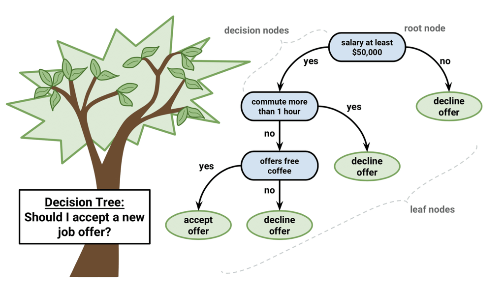

The critical part is how to split ? i.e. The best split.

- Gini impurity (Tsallis Entropy) *[Theory lecture, next session]*
- Information gain (which tell us how well an attribute splits the data) *[Theory lecture, next session]*.

### Some code

##### Getting a tree

Skipping the details about the splitting (for now), this is how we do it with the *tidyverse* suite.

```r
library(tidymodels)
library(rpart)
```

```r
library(rpart.plot)
```

Let’s play around with some portion of titanic’s tragedy.

```r
data(ptitanic)
ptitanic %>% View()
str(ptitanic)
```

```
## 'data.frame':    1309 obs. of  6 variables:
##  $ pclass  : Factor w/ 3 levels "1st","2nd","3rd": 1 1 1 1 1 1 1 1 1 1 ...
##  $ survived: Factor w/ 2 levels "died","survived": 2 2 1 1 1 2 2 1 2 1 ...
##  $ sex     : Factor w/ 2 levels "female","male": 1 2 1 2 1 2 1 2 1 2 ...
##  $ age     : 'labelled' num  29 0.917 2 30 25 ...
##   ..- attr(*, "units")= chr "Year"
##   ..- attr(*, "label")= chr "Age"
##  $ sibsp   : 'labelled' int  0 1 1 1 1 0 1 0 2 0 ...
##   ..- attr(*, "label")= chr "Number of Siblings/Spouses Aboard"
##  $ parch   : 'labelled' int  0 2 2 2 2 0 0 0 0 0 ...
##   ..- attr(*, "label")= chr "Number of Parents/Children Aboard"
```

```r
model_tree <-
  decision_tree(cost_complexity = 0.004) %>%
  set_engine("rpart") %>%
  set_mode("classification") %>%
  translate()
model_tree
```

```
## Decision Tree Model Specification (classification)
##
## Main Arguments:
##   cost_complexity = 0.004
##
## Computational engine: rpart
##
## Model fit template:
## rpart::rpart(formula = missing_arg(), data = missing_arg(), weights = missing_arg(),
##     cp = 0.004)
```

Or we could call directly to **rpart**. See example below.

```r
survived_verse <- model_tree %>%
  fit(survived ~ ., data = ptitanic)
survived_verse
```

```
## parsnip model object
##
## Fit time:  25ms
## n= 1309
##
## node), split, n, loss, yval, (yprob)
##       * denotes terminal node
##
##   1) root 1309 500 died (0.6180290 0.3819710)
##     2) sex=male 843 161 died (0.8090154 0.1909846)
##       4) age>=9.5 796 136 died (0.8291457 0.1708543) *
##       5) age< 9.5 47  22 survived (0.4680851 0.5319149)
##        10) sibsp>=2.5 20   1 died (0.9500000 0.0500000) *
##        11) sibsp< 2.5 27   3 survived (0.1111111 0.8888889) *
##     3) sex=female 466 127 survived (0.2725322 0.7274678)
##       6) pclass=3rd 216 106 died (0.5092593 0.4907407)
##        12) sibsp>=2.5 21   3 died (0.8571429 0.1428571) *
##        13) sibsp< 2.5 195  92 survived (0.4717949 0.5282051)
##          26) age>=16.5 162  79 died (0.5123457 0.4876543)
##            52) parch>=3.5 9   1 died (0.8888889 0.1111111) *
##            53) parch< 3.5 153  75 survived (0.4901961 0.5098039)
##             106) age>=27.5 44  17 died (0.6136364 0.3863636) *
##             107) age< 27.5 109  48 survived (0.4403670 0.5596330)
##               214) age< 21.5 28  11 died (0.6071429 0.3928571) *
##               215) age>=21.5 81  31 survived (0.3827160 0.6172840) *
##          27) age< 16.5 33   9 survived (0.2727273 0.7272727) *
##       7) pclass=1st,2nd 250  17 survived (0.0680000 0.9320000) *
```

Or just using **rpart**.

```r
survived <- rpart(survived ~ ., data = ptitanic, cp = 0.02)
survived
```

```
## n= 1309
##
## node), split, n, loss, yval, (yprob)
##       * denotes terminal node
##
##  1) root 1309 500 died (0.6180290 0.3819710)
##    2) sex=male 843 161 died (0.8090154 0.1909846)
##      4) age>=9.5 796 136 died (0.8291457 0.1708543) *
##      5) age< 9.5 47  22 survived (0.4680851 0.5319149)
##       10) sibsp>=2.5 20   1 died (0.9500000 0.0500000) *
##       11) sibsp< 2.5 27   3 survived (0.1111111 0.8888889) *
##    3) sex=female 466 127 survived (0.2725322 0.7274678) *
```

```r
# all  the details
summary(survived)
```

```
## Call:
## rpart(formula = survived ~ ., data = ptitanic, cp = 0.02)
##   n= 1309
##
##      CP nsplit rel error xerror       xstd
## 1 0.424      0     1.000  1.000 0.03515762
## 2 0.021      1     0.576  0.576 0.02997570
## 3 0.020      3     0.534  0.564 0.02974883
##
## Variable importance
##    sex  sibsp  parch    age pclass
##     77      8      7      6      3
##
## Node number 1: 1309 observations,    complexity param=0.424
##   predicted class=died      expected loss=0.381971  P(node) =1
##     class counts:   809   500
##    probabilities: 0.618 0.382
##   left son=2 (843 obs) right son=3 (466 obs)
##   Primary splits:
##       sex    splits as  RL,      improve=172.749200, (0 missing)
##       pclass splits as  RRL,     improve= 49.647030, (0 missing)
##       parch  < 0.5 to the left,  improve= 18.588590, (0 missing)
##       age    < 8.5 to the right, improve=  8.228231, (263 missing)
##       sibsp  < 0.5 to the left,  improve=  6.902501, (0 missing)
##   Surrogate splits:
##       parch < 0.5 to the left,  agree=0.674, adj=0.084, (0 split)
##
## Node number 2: 843 observations,    complexity param=0.021
##   predicted class=died      expected loss=0.1909846  P(node) =0.6440031
##     class counts:   682   161
##    probabilities: 0.809 0.191
##   left son=4 (796 obs) right son=5 (47 obs)
##   Primary splits:
##       age    < 9.5 to the right, improve=13.024220, (185 missing)
##       pclass splits as  RLL,     improve=10.198870, (0 missing)
##       parch  < 0.5 to the left,  improve= 5.377837, (0 missing)
##       sibsp  < 3.5 to the right, improve= 1.101561, (0 missing)
##   Surrogate splits:
##       sibsp < 3.5 to the left,  agree=0.944, adj=0.14, (185 split)
##
```

[output cut: 18 more lines]

```
##       age    < 3.5 to the right, improve= 0.9085875, (4 missing)
##       parch  < 1.5 to the right, improve= 0.4672183, (0 missing)
##   Surrogate splits:
##       pclass splits as  RRL,     agree=0.723, adj=0.35, (0 split)
##       parch  < 1.5 to the right, agree=0.617, adj=0.10, (0 split)
##
## Node number 10: 20 observations
##   predicted class=died      expected loss=0.05  P(node) =0.01527884
##     class counts:    19     1
##    probabilities: 0.950 0.050
##
## Node number 11: 27 observations
##   predicted class=survived  expected loss=0.1111111  P(node) =0.02062643
##     class counts:     3    24
##    probabilities: 0.111 0.889
```

Remember: always ask for help.

```r
?rpart
#?decision_tree
```

And now we can plot the trees (inverted trees actually).

- Another possible way to plot them is by using https://cran.r-project.org/web/packages/ggparty/vignettes/ggparty-graphic-partying.html

### - Option 1.

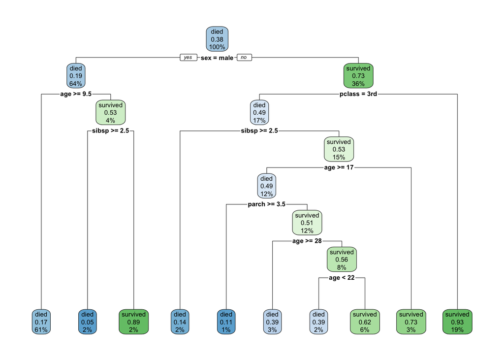

```r
rpart.plot(survived_verse$fit, roundint=FALSE)
```

Each node shows

- the predicted class (died or survived),
- the predicted probability of survival,
- the percentage of observations in the node.

### - Option 2 (with more fine-tunning)

For more info go to http://www.milbo.org/rpart-plot/prp.pdf

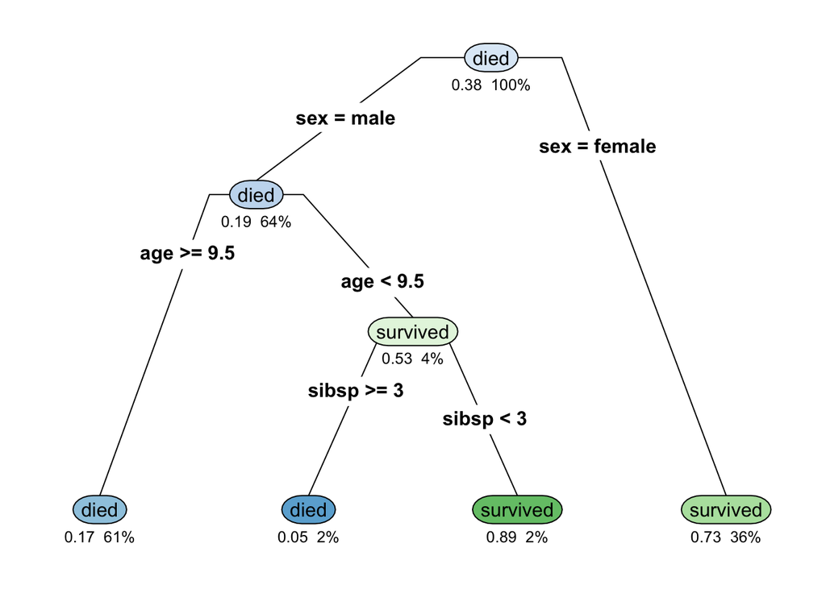

```r
rpart.plot(survived, type = 4, clip.right.labs = FALSE, branch = .3, under = TRUE)
```

What about cp ?? how fast do we reach this treshold.

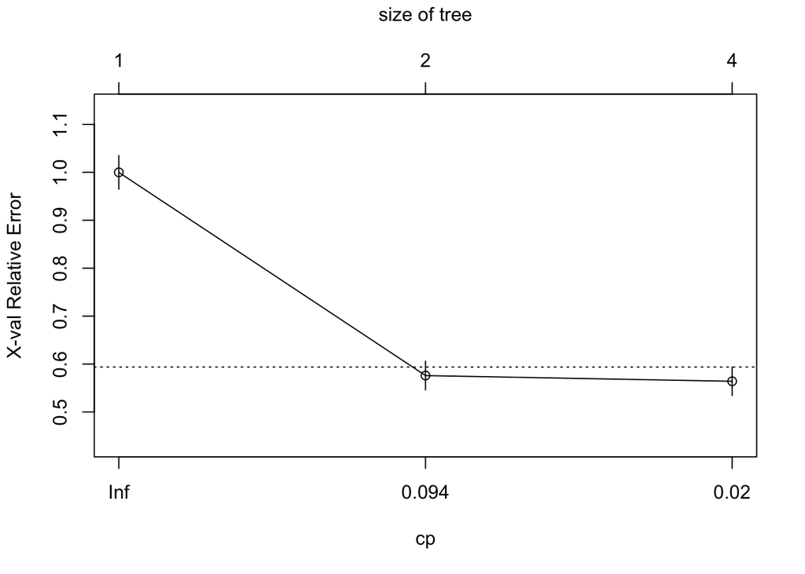

```r
rpart::plotcp(survived)
```

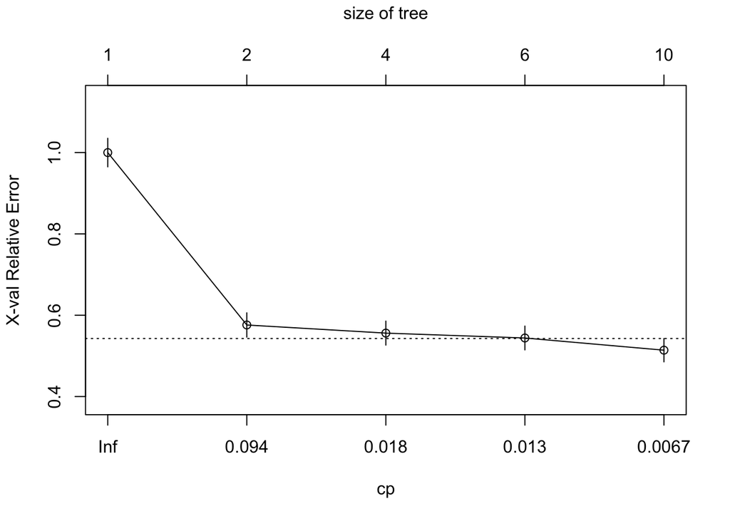

```r
rpart::plotcp(survived_verse$fit)
```

```r
# This looks a little bit different, so it seems that there small differences after all.
```

Play a little bit with this parameter, **cp**, and see how our results change.

```r
ptitanic[1:3,]
```

```
##   pclass survived    sex     age sibsp parch
## 1    1st survived female 29.0000     0     0
## 2    1st survived   male  0.9167     1     2
## 3    1st     died female  2.0000     1     2
```

```r
rpart.predict(survived, newdata=ptitanic[1:3,], rules=TRUE)
```

```
##        died  survived
## 1 0.2725322 0.7274678 because sex is female
## 2 0.1111111 0.8888889 because sex is   male & age <  9.5 & sibsp <  3
## 3 0.2725322 0.7274678 because sex is female
```

```r
?rpart.predict
```

```r
rpart.rules(survived)
```

```
##  survived
##      0.05 when sex is   male & age <  9.5 & sibsp >= 3
##      0.17 when sex is   male & age >= 9.5
##      0.73 when sex is female
##      0.89 when sex is   male & age <  9.5 & sibsp <  3
```

- Independet work: work with the **Carseats** dataset, install the **ISLR** package.

```r
library(ISLR)
#data(package="ISLR")
carseats<-Carseats
str(carseats)
```

```
## 'data.frame':    400 obs. of  11 variables:
##  $ Sales      : num  9.5 11.22 10.06 7.4 4.15 ...
##  $ CompPrice  : num  138 111 113 117 141 124 115 136 132 132 ...
##  $ Income     : num  73 48 35 100 64 113 105 81 110 113 ...
##  $ Advertising: num  11 16 10 4 3 13 0 15 0 0 ...
##  $ Population : num  276 260 269 466 340 501 45 425 108 131 ...
##  $ Price      : num  120 83 80 97 128 72 108 120 124 124 ...
##  $ ShelveLoc  : Factor w/ 3 levels "Bad","Good","Medium": 1 2 3 3 1 1 3 2 3 3 ...
##  $ Age        : num  42 65 59 55 38 78 71 67 76 76 ...
##  $ Education  : num  17 10 12 14 13 16 15 10 10 17 ...
##  $ Urban      : Factor w/ 2 levels "No","Yes": 2 2 2 2 2 1 2 2 1 1 ...
##  $ US         : Factor w/ 2 levels "No","Yes": 2 2 2 2 1 2 1 2 1 2 ...
```

Observe that **Sales** is a quantitative variable (show this with a plot). You want to demonstrate it using trees with a binary response. To do so, you turn **Sales** into a binary variable, which will be called High. If the sales is less than 8, it will be not high. Otherwise, it will be high. Then you can put that new variable High back into the dataframe.

- plot

```r
?Carseats
```

```r
High = ifelse(carseats$Sales<=8, "No", "Yes")
carseats = data.frame(carseats, High)
summary(carseats)
```

```
##      Sales          CompPrice       Income        Advertising
##  Min.   : 0.000   Min.   : 77   Min.   : 21.00   Min.   : 0.000
##  1st Qu.: 5.390   1st Qu.:115   1st Qu.: 42.75   1st Qu.: 0.000
##  Median : 7.490   Median :125   Median : 69.00   Median : 5.000
##  Mean   : 7.496   Mean   :125   Mean   : 68.66   Mean   : 6.635
##  3rd Qu.: 9.320   3rd Qu.:135   3rd Qu.: 91.00   3rd Qu.:12.000
##  Max.   :16.270   Max.   :175   Max.   :120.00   Max.   :29.000
##    Population        Price        ShelveLoc        Age          Education
##  Min.   : 10.0   Min.   : 24.0   Bad   : 96   Min.   :25.00   Min.   :10.0
##  1st Qu.:139.0   1st Qu.:100.0   Good  : 85   1st Qu.:39.75   1st Qu.:12.0
##  Median :272.0   Median :117.0   Medium:219   Median :54.50   Median :14.0
##  Mean   :264.8   Mean   :115.8                Mean   :53.32   Mean   :13.9
##  3rd Qu.:398.5   3rd Qu.:131.0                3rd Qu.:66.00   3rd Qu.:16.0
##  Max.   :509.0   Max.   :191.0                Max.   :80.00   Max.   :18.0
##  Urban       US          High
##  No :118   No :142   Length:400
##  Yes:282   Yes:258   Class :character
##                      Mode  :character
##
##
##
```

- Activity 2. Obtain the decission tree for the *iris* data set.